# Breast Cancer Analysis

Steven Hernandez

2023-04-16

### Goal

This analysis will investigate potential factors towards a patient’s survival of breast cancer.

Such as:

- Protein Evaluation Levels
- Type of Surgery
- Stage of Cancer
- Patient’s Age

Understanding what may influence survival could help more people struggling with breast cancer.

## Understanding the Data

Data was obtained from [Kaggle](https://www.kaggle.com/datasets/kreeshrajani/breast-cancer-survival-dataset)

### Libraries

```r
# Loading libraries necessary for analysis
library(tidyverse)
library(janitor)
library(ggpubr) # Obtain function needed for Correlation Coefficient
```

### View the Data

- View the first few rows to see how the data was organized

```r
cancer_data <- read_csv('Breast_Cancer_Data.csv')
```

TABLE 1.1: Glimpse of the Data

| Age | Gender | Protein1 | Protein2 | Protein3 | Protein4 | Tumour_Stage | Histology | Surgery_type | Surgery_Date | Last_Visit_Date | Patient_Status | Surgery_Year |
| --- | --- | --- | --- | --- | --- | --- | --- | --- | --- | --- | --- | --- |
| 36 | FEMALE | 0.08 | 0.43 | 0.55 | 0.27 | III | Infiltrating Ductal Carcinoma | Modified Radical Mastectomy | 2017-01-15 | 2017-06-19 | Alive | 2017 |
| 56 | FEMALE | 0.35 | -0.21 | -0.19 | 0.12 | II | Infiltrating Ductal Carcinoma | Modified Radical Mastectomy | 2017-01-25 | 2017-07-12 | Alive | 2017 |
| 53 | FEMALE | -0.07 | 1.42 | -0.36 | 0.39 | II | Infiltrating Ductal Carcinoma | Simple Mastectomy | 2017-02-04 | 2018-02-07 | Alive | 2017 |
| 40 | FEMALE | -0.57 | 1.27 | -0.29 | 0.19 | II | Infiltrating Lobular Carcinoma | Other | 2017-02-14 | 2017-12-15 | Alive | 2017 |
| 75 | FEMALE | 0.17 | 0.03 | -0.16 | 0.67 | I | Infiltrating Lobular Carcinoma | Simple Mastectomy | 2017-02-24 | 2017-04-05 | Alive | 2017 |
| 41 | FEMALE | 0.14 | 1.08 | 0.21 | 0.97 | I | Infiltrating Lobular Carcinoma | Simple Mastectomy | 2017-03-06 | 2019-08-09 | Alive | 2017 |

### Data’s Structure

- View the column names

```r
colnames(cancer_data)
```

```
##  [1] "Age"             "Gender"          "Protein1"        "Protein2"
##  [5] "Protein3"        "Protein4"        "Tumour_Stage"    "Histology"
##  [9] "Surgery_type"    "Surgery_Date"    "Last_Visit_Date" "Patient_Status"
## [13] "Surgery_Year"
```

- There are *334* different patients with *13* columns of patient information

```r
glimpse(cancer_data)
```

```
## Rows: 334
## Columns: 13
## $ Age             <dbl> 36, 56, 53, 40, 75, 41, 62, 45, 62, 50, 61, 43, 74, 56…
## $ Gender          <chr> "FEMALE", "FEMALE", "FEMALE", "FEMALE", "FEMALE", "FEM…
## $ Protein1        <dbl> 0.080353, 0.345090, -0.069535, -0.565700, 0.171640, 0.…
## $ Protein2        <dbl> 0.426380, -0.211470, 1.418300, 1.266800, 0.029656, 1.0…
## $ Protein3        <dbl> 0.547150, -0.193040, -0.361050, -0.293460, -0.158900, …
## $ Protein4        <dbl> 0.273680, 0.124270, 0.391580, 0.193950, 0.674710, 0.97…
## $ Tumour_Stage    <chr> "III", "II", "II", "II", "I", "I", "II", "I", "II", "I…
## $ Histology       <chr> "Infiltrating Ductal Carcinoma", "Infiltrating Ductal …
## $ Surgery_type    <chr> "Modified Radical Mastectomy", "Modified Radical Maste…
## $ Surgery_Date    <date> 2017-01-15, 2017-01-25, 2017-02-04, 2017-02-14, 2017-…
## $ Last_Visit_Date <date> 2017-06-19, 2017-07-12, 2018-02-07, 2017-12-15, 2017-…
## $ Patient_Status  <chr> "Alive", "Alive", "Alive", "Alive", "Alive", "Alive", …
## $ Surgery_Year    <dbl> 2017, 2017, 2017, 2017, 2017, 2017, 2017, 2017, 2017, …
```

## Comparing Data Statistics

The following tables highlight:

- The amount of patients
- Average expression levels of Proteins 1 - 4
- Percentage of Patients alive
- Amount of patients whose survival status is unknown
- Percentage highlighting the amount of cases of stages 1-3
- The following table shows the statistics between **all 334 patients**:

TABLE 2.1: Data Set Statistics

| Patients | Protein 1 | Protein 2 | Protein 3 | Protein 4 | Survival Rate | Unknown | Stage I | Stage II | Stage III |
| --- | --- | --- | --- | --- | --- | --- | --- | --- | --- |
| 334 | -0.03 | 0.95 | -0.09 | 0.01 | 76.35% | 13 | 19% | 57% | 24% |

- Splitting the data by the *year* a patient had their surgery:

TABLE 2.2: Yearly Statistics

| Surgery Year | Patients | Protein 1 | Protein 2 | Protein 3 | Protein 4 | Survival Rate | Unknown | Stage I | Stage II | Stage III |
| --- | --- | --- | --- | --- | --- | --- | --- | --- | --- | --- |
| 2017 | 61 | 0.08 | 0.94 | -0.09 | 0.16 | 75.41% | 3 | 25% | 57% | 18% |
| 2018 | 152 | -0.07 | 0.91 | -0.14 | -0.10 | 77.63% | 4 | 18% | 56% | 26% |
| 2019 | 121 | -0.03 | 1.00 | -0.02 | 0.07 | 75.21% | 6 | 17% | 57% | 26% |

Result:

- The survival rate is consistent throughout the data
  - About 75%-77%
- 2018-2019 had similar percentages across stages 1-3
  - 2017’s difference possibly stems from smaller pool of patients
- The Patients whose status is unknown is spread unevenly
  - Lack of information in data set

Future analysis needed to grasp the difference between the Protein expression levels throughout the years.

## Comparing Protein Expression Levels

The following graphs’ axis are the patient’s **expression levels** for two different proteins

- Expression Levels: State how proteins are *maintained* and *changed*
- Goal: To identify if there is a relationship between 2 Proteins that can help identify a patient’s survival

### Protein 1 vs 2

#### Chart

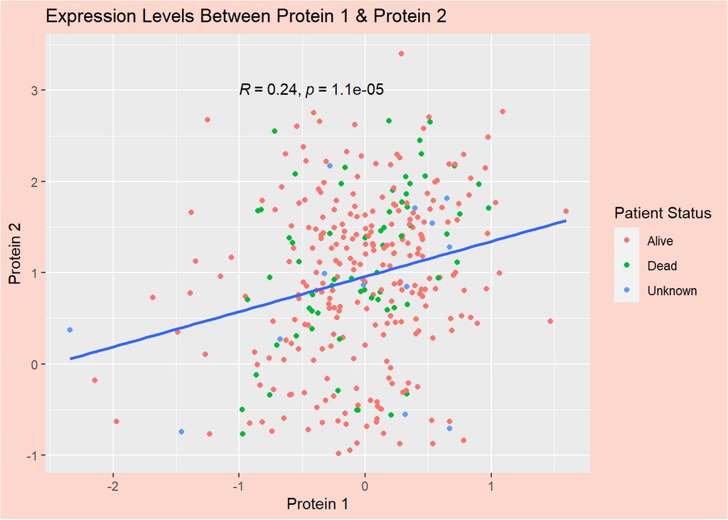

#### Code

```
ggplot(data = cancer_data,mapping= aes(x = protein1,y = protein2)) +
  geom_point(aes(color = patient_status)) +
  geom_smooth(method = lm, se = FALSE) +
  stat_cor(method = "pearson", label.x = -1, label.y = 3) +
  labs(title = "Expression Levels Between Protein 1 & Protein 2",
       x = "Protein 1",
       y = "Protein 2",
       color = "Patient Status") +
  theme(plot.background = element_rect(fill = '#FBD7CD'),
        legend.background = element_rect(fill = "#FBD7CD"))
```

### Protein 1 vs 3

#### Chart

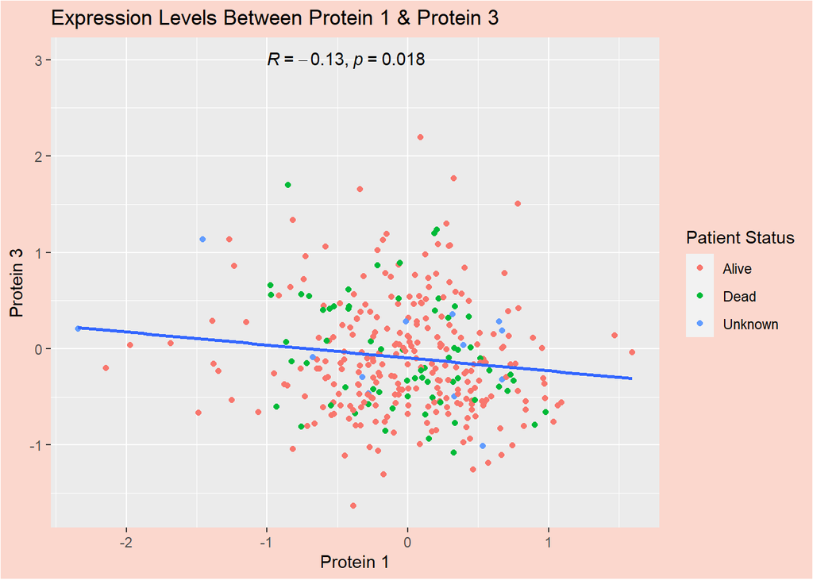

#### Code

```
ggplot(data = cancer_data,mapping = aes(x = protein1,y=protein3)) +
  geom_point(aes(color = patient_status)) +
  geom_smooth(method = lm, se = FALSE) +
  stat_cor(method = "pearson", label.x = -1, label.y = 3) +
  labs(title = "Expression Levels Between Protein 1 & Protein 3",
       x = "Protein 1",
       y = "Protein 3",
       color = "Patient Status") +
  theme(plot.background = element_rect(fill = '#FBD7CD'),
        legend.background = element_rect(fill = "#FBD7CD"))
```

### Protein 1 vs 4

#### Chart

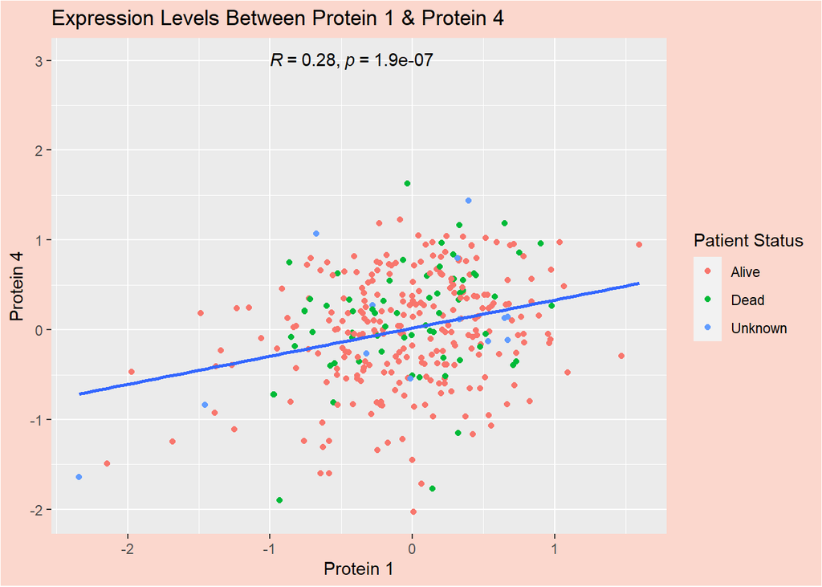

#### Code

```
ggplot(data = cancer_data, mapping = aes(x = protein1,y=protein4)) +
  geom_point(aes(color = patient_status)) +
  geom_smooth(method = lm, se = FALSE) +
  stat_cor(method = "pearson", label.x = -1, label.y = 3) +
  labs(title = "Expression Levels Between Protein 1 & Protein 4",
       x = "Protein 1",
       y = "Protein 4",
       color = "Patient Status") +
  theme(plot.background = element_rect(fill = '#FBD7CD'),
        legend.background = element_rect(fill = "#FBD7CD"))
```

### Protein 2 vs 3

#### Chart

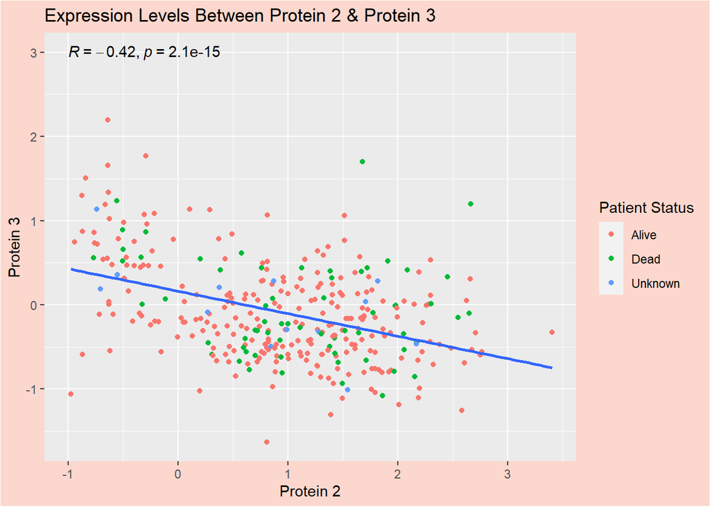

#### Code

```
ggplot(data = cancer_data, mapping = aes(x = protein2,y=protein3)) +
  geom_point(aes(color = patient_status)) +
  geom_smooth(method = lm, se = FALSE) +
  stat_cor(method = "pearson", label.x = -1, label.y = 3) +
  labs(title = "Expression Levels Between Protein 2 & Protein 3",
       x = "Protein 2",
       y = "Protein 3",
       color = "Patient Status") +
  theme(plot.background = element_rect(fill = '#FBD7CD'),
        legend.background = element_rect(fill = "#FBD7CD"))
```

### Protein 2 vs 4

#### Chart

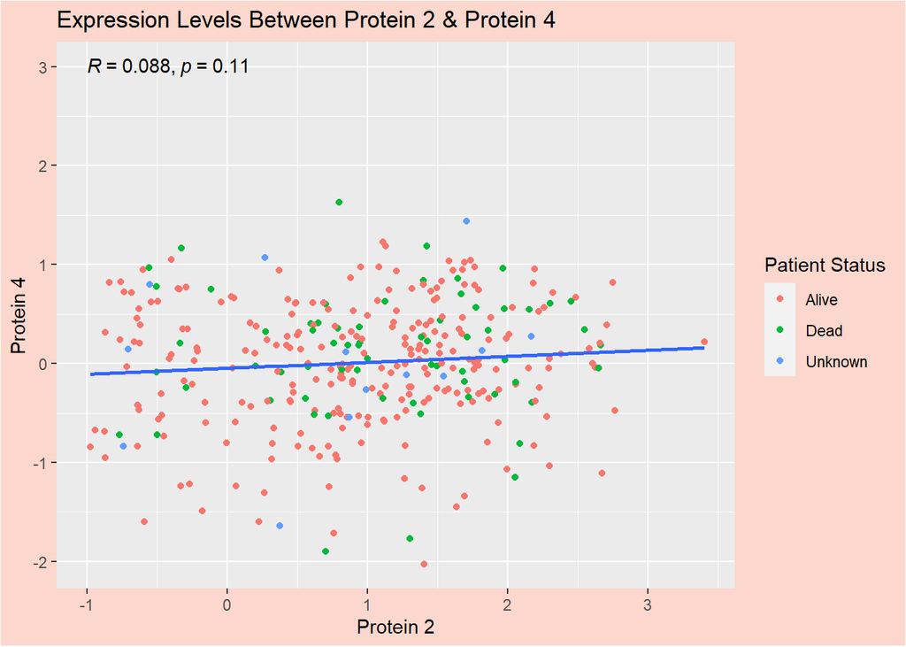

- Protein 2 and Protein 4 have an insignificant positive correlation
  - R Value: **0.088**
- The p value indicates this is *unreliable* result
  - Some form of bias in data

#### Code

```
ggplot(data = cancer_data, mapping = aes(x = protein2,y=protein4)) +
  geom_point(aes(color = patient_status)) +
  geom_smooth(method = lm, se = FALSE) +
  stat_cor(method = "pearson", label.x = -1, label.y = 3) +
  labs(title = "Expression Levels Between Protein 2 & Protein 4",
       x = "Protein 2",
       y = "Protein 4",
       color = "Patient Status") +
  theme(plot.background = element_rect(fill = '#FBD7CD'),
        legend.background = element_rect(fill = "#FBD7CD"))
```

### Protein 3 vs 4

#### Chart

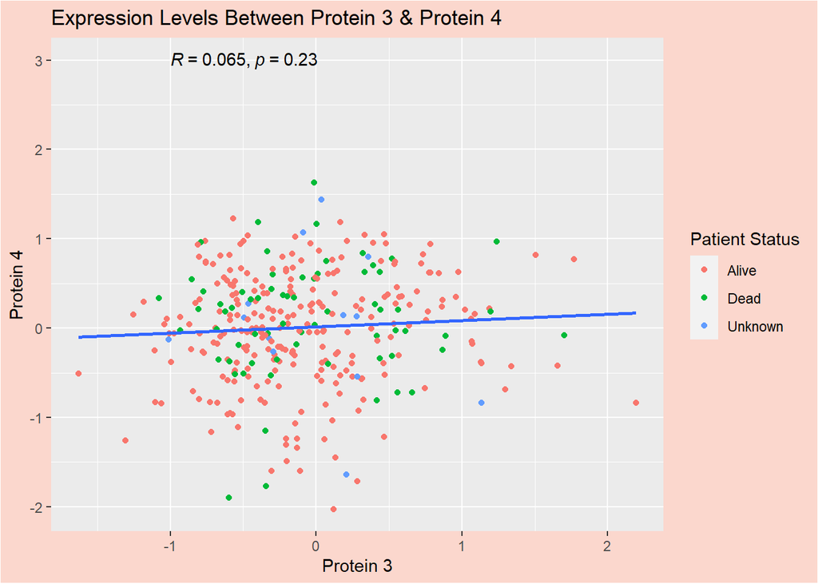

- Protein 3 and Protein 4 have an insignificant positive correlation
  - R Value: **0.065**
- The p value indicates this is *unreliable* result
  - Some form of bias in data

#### Code

```
ggplot(data = cancer_data, mapping = aes(x = protein3,y=protein4)) +
  geom_point(aes(color = patient_status)) +
  geom_smooth(method = lm, se = FALSE) +
  stat_cor(method = "pearson", label.x = -1, label.y = 3) +
  labs(title = "Expression Levels Between Protein 3 & Protein 4",
       x = "Protein 3",
       y = "Protein 4",
       color = "Patient Status") +
  theme(plot.background = element_rect(fill = '#FBD7CD'),
        legend.background = element_rect(fill = "#FBD7CD"))
```

### Conclusion

- The Protein Expression levels hold **no strong correlation** with each other
  - Cannot be used to predict a patient’s expression levels
  - **Unreliable** patterns such as:
    - No deceased patients when protein 1 and protein 2 are low
    - Could be sample bias
  - No discernible pattern with patient survival

## Surgery Type

Next is an attempt to identify whether the **type** of surgery patient their **survival** later in life

- Try to see if the cancer’s stage affects the results

### Chart

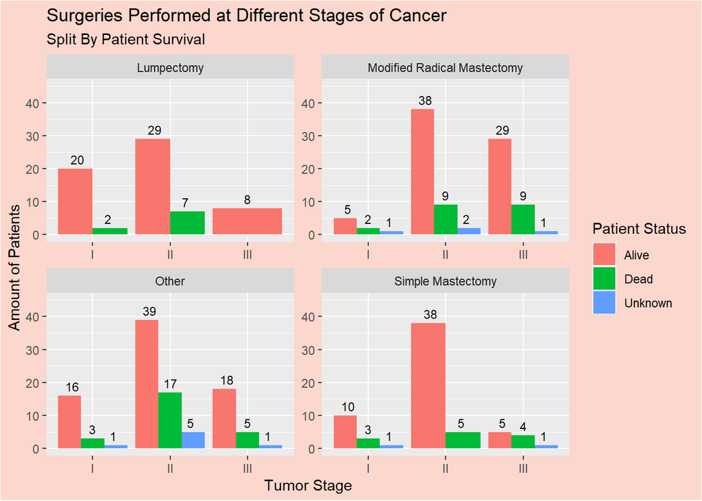

### Code

```
# Grouped  bar chart showing the patient status for each surgery type divided by cancer stage
ggplot(data = cancer_data, aes(x = tumour_stage))+
  geom_bar(aes(fill = patient_status),position = 'dodge') +
  geom_text(aes(label = after_stat(count),group = patient_status), stat ="count",
            size = 3, position = position_dodge(0.8), vjust=-0.5) +
  facet_wrap(~surgery_type,scales = 'free')  +
  ylim(0,45) +
  labs(title = "Surgeries Performed at Different Stages of Cancer",
       subtitle = "Split By Patient Survival",
       x = "Tumor Stage",
       y = "Amount of Patients",
       fill = "Patient Status") +
  theme(plot.background = element_rect(fill = '#FBD7CD'),
        legend.background = element_rect(fill = "#FBD7CD"))
```

**Stage 1:**

- *Lumpectomy* had the **most** patients alive and tied for the least deceased
- *Modified Radical Mastectomy* most concerning when 5 alive and 2 deceased
  - Seems unreliable

**Stage 2:**

- *Simple Mastectomy* had **38** alive patients, while having the *least deceased* (5)
- *Modified Radical Mastectomy* had same amount of alive patients, but almost *twice* as many later deceased (9)
- *Lumpectomy* had **least** patients alive (29), while having concerning amount of deaths (7)
- Other types of surgeries are the most concerning with 17 patients dead and 39 alive

**Stage 3:**

- *Lumpectomy* remarkably had **no** deaths, with 8 alive
- *Simple Mastectomy* is **unreliable** with 5 alive and 4 dead
- *Modified Radical Mastectomy* has a good ratio for an advanced cancer stage
  - 29 Alive, 9 deceased

**Conclusion**:

The type of surgery seems to correlate with the likelihood a patient will live years after surgery.

Some surgeries perform far better in different stages:

- **Lumpectomy** is the most reliable for stage 1, and great for stage 3
- **Simple Mastectomy** has favorable results for stage 2
- **Modified Radical Mastectomy** has consistent patterns for stage 2 & 3

**Limitation**:

The data set doesn’t specify if the patient’s cause of death is related to the cancer **or** the result of something else.

- Further analysis is needed for clarification

## Cancer Stages Spread Across Ages

The goal is to identify how patient’s ages spread in the data set.

- What ages have the most instances of cancer
- How different stages of cancer is spread by age
- Identify patterns between patients that are alive or deceased

### Chart

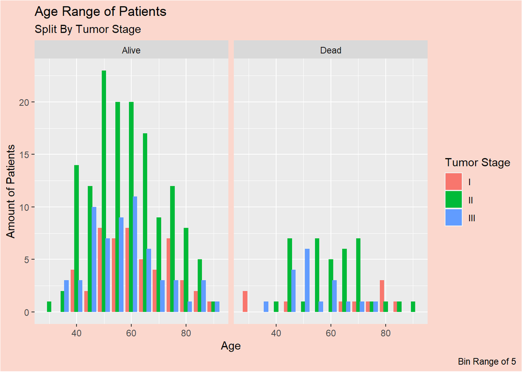

### Code

```
cancer_data %>%
  filter(patient_status != 'Unknown') %>%
  ggplot() +
    geom_histogram(aes(x = age, fill = tumour_stage),position = position_dodge(4),
                    binwidth = 5) +
    labs(title = "Age Range of Patients",
         subtitle = "Split By Tumor Stage",
         x = "Age",
         y = "Amount of Patients",
         fill = "Tumor Stage",
         caption = "Bin Range of 5") +
    theme(plot.background = element_rect(fill = '#FBD7CD'),
          legend.background = element_rect(fill = "#FBD7CD"),
          plot.caption.position = 'plot') +
    facet_wrap(~patient_status)
```

There is a notable bell curve in the data:

- Most of the data is between ages 40-80 for both groups

Patients that are **alive**:

- Most cases between ages 40-80 see Stage 2 as the most common diagnosed
  - Stage 1 and 3 are both prominent between 40-80 as well
- Cases rise as patients grow closer to 60, but decrease the older patients are

Patients that are **deceased**:

- Very rarely did a patient die from Stage 1, regardless of age.
- Most cases of death were patients diagnosed with Stage 2 or 3
  - Stage 3 being prominent between late 40s and late 50s
- Rise in cases between late 40s and 70s, but a significant decrease afterwards.

## Patient Survival By Surgery Year

Next, it is to investigate whether the year a patient had their surgery would affect their chances of a future.

### Chart

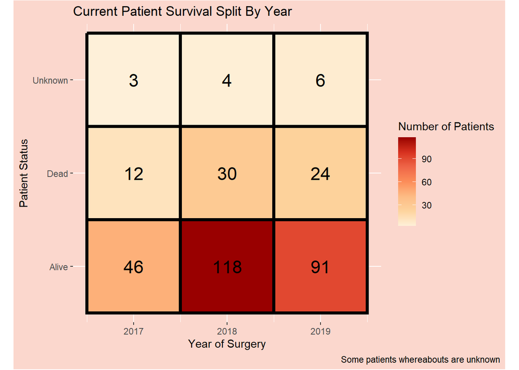

It is unlikely the year a patient had their surgery would affect their chances of survival.

### Code

```
cancer_data %>%
  group_by(surgery_year,patient_status) %>%
  summarize(count = n()) %>%
  ggplot(mapping =aes(x = surgery_year, y = patient_status,fill = count)) +
    geom_tile(color = 'black', lwd = 1.5,) +
    geom_text(aes(label = count), color = 'black',size = 6) +
    coord_fixed() +
  scale_fill_distiller(palette = 'OrRd',direction = +1) +
  labs(title = "Current Patient Survival Split By Year",
       y = "Patient Status",
       x = "Year of Surgery",
       fill = "Number of Patients",
       caption = 'Some patients whereabouts are unknown') +
  theme(plot.background = element_rect(fill = '#FBD7CD'),
        panel.background = element_rect(fill = '#FBD7CD'),
        legend.background = element_rect(fill = "#FBD7CD"),
        plot.caption.position = 'plot')
```

# Breast Cancer Dashboard

Summarizes key points discussed:

- Stages of cancer between ages
- Scatter plots for protein expression levels
- Survival rate of different surgeries

Additionally, filters allow for a more in-depth look at the data

- Most filters are connected between all three charts
- Age Range applies to *Different Stages of Cancer Split By Age* & *Protein Expression Levels*

Allows for user to specify:

- Age range
- Stage of Cancer
- Type of Breast Cancer
- Patient’s Status (Alive, Dead, or Unknown)

[figure not shown]

The Histology filter helps further identify any patterns among the different surgeries

#### **Stage 1**

- Lumpectomy had two patients deceased for Stage 1
  - Both are from an Infiltrating Ductal Carcinoma
  - 3-0 for Infiltrating Lobular Carcinoma & 2-0 Mucinous Carcinoma
- Modified Radical Masectomy performance dependent on type of cancer:
  - Infiltrating Ductal Carcinoma: 4-2
  - Mucinous Carcinoma : 1-0

#### **Stage 2**

- Previously stated *Simple Mastectomy* had **38** alive patients, while having the *least deceased* (5)
  - Filter showed it performs best against Infiltrating Ductal Carcinoma (21-4) but not as impressive against Infiltrating Lobular Carcinoma
    - *Simple Mastectomy* : 7-1
    - *Modified Radical Mastectomy* : 13-1
    - *Lumpectomy* : 7-1
- *Lumpectomy* was shown to have the **least** patients alive (29), while having concerning amount of deaths (7)
  - Yet filters highlight its good performance against Infiltrating Ductal Carcinoma (21-4) & Infiltrating Lobular Carcinoma (7-1)
  - Performed poorly against Mucinous Carcinoma (1-2)

#### **Stage 3**

- *Lumpectomy* had **no** deaths against Infiltrating Ductal Carcinoma & Infiltrating Lobular Carcinoma
  - No patients had Mucinous Carcinoma for Stage 3
- *Simple Mastectomy* is still **unreliable** against Infiltrating Ductal Carcinoma (4-4)
  - Although against Infiltrating Lobular Carcinoma it had no deaths (1-0)
- *Modified Radical Mastectomy* is great against Infiltrating Ductal Carcinoma (23-4)
  - Conscerning against Infiltrating Lobular Carcinoma (6-5)

#### **Conclusion**

Utilizing filters allowed for a deeper analysis on the performances of different surgeries

- Highlights which surgeries were better for which type of breast cancer

These factors seem to influence a patient’s chances of survival post-surgery:

- Different stages of cancer
- The type of Breast Cancer
- The type of Surgery

## Final Thoughts

- It is unlikely the year a patient had their surgery would affect their chances of survival.
  - The survival rate is consistent
    - About 75%-77%
- The Protein Expression levels hold **no strong correlation** with each other
  - Cannot be used to predict a patient’s expression levels
  - No discernible pattern with patient survival
- Those with cancer are likely to be between ages 40-80
  - Stage 2 is the most common
  - Cases rise as patients grow closer to 60, but decrease the older patients are
  - Very rarely did a patient die from Stage 1, regardless of age.
- Factors seemingly influence a patient’s chances of survival post-surgery:
  - Different stages of cancer
  - The type of Breast Cancer
  - The type of Surgery

**Limitations**:

- Unspecific cause of death
- Lack of information on the “Unknown” Patients
- Possible sample bias in data set
- Unequal spread of type of cancer patients had

Further analysis needed to ensure these limitations didn’t impact the results.